# Project: Investigate the FBI Gun Dataset

- Introduction
- Data Wrangling
- Exploratory Data Analysis
- Conclusions

# Introduction

*The data comes from the FBI'sNational Instant Criminal BackgroundCheck System. The NICS is used by todetermine whether a prospectivebuyer is eligible to buy firearms orexplosives. Gun shops call into thissystem to ensure that each customerdoes not have a criminal record orisn’t otherwise ineligible to make apurchase. The data has beensupplemented with state level datafrom census.gov.*

**●The NICS data is found in onesheet of an .xlsx file. It containsthe number of firearm checks bymonth, state, and type.**

**●The U.S. census data is foundin a .csv file. It contains severalvariables at the state level. Mostvariables just have one datapoint per state (2016), but a fewhave data for more than oneyear.**

# Questions:

**1- What was the highest state in applying for permits in 19 years?**

**2-Which state has the least state for permits in 19 years?**

**3-What census data is most associated with high gun per capita?**

**4-What census data is minimum associated with gun per capita?**

**5-Which state has had the highest growth rate in weapons registrations?**

**6-Which state has had the least growth rate in weapons registrations?**

# Data wrangling

```python
#Importing the necessary library
import pandas as pd
import numpy as np
import matplotlib.pyplot as plt
import seaborn as sb

%matplotlib inline
```

# Data gathering

```python
#loading data
read_file  = pd.read_excel("gun-data.xlsx")
read_file.to_csv ('gun-data.csv', index = None, header=True)
df_gun = pd.read_csv("gun-data.csv")
df_census = pd.read_csv("u.s.-census-data.csv")
```

# Assessing Data

### Visual Assessment

```python
df_gun
```

|  | month | state | permit | permit_recheck | handgun | long_gun | other | multiple | admin | prepawn_handgun | ... | returned_other | rentals_handgun | rentals_long_gun | private_sale_handgun | private_sale_long_gun | private_sale_other | return_to_seller_handgun | return_to_seller_long_gun | return_to_seller_other | totals |
| --- | --- | --- | --- | --- | --- | --- | --- | --- | --- | --- | --- | --- | --- | --- | --- | --- | --- | --- | --- | --- | --- |
| 0 | 2017-09 | Alabama | 16717.0 | 0.0 | 5734.0 | 6320.0 | 221.0 | 317 | 0.0 | 15.0 | ... | 0.0 | 0.0 | 0.0 | 9.0 | 16.0 | 3.0 | 0.0 | 0.0 | 3.0 | 32019 |
| 1 | 2017-09 | Alaska | 209.0 | 2.0 | 2320.0 | 2930.0 | 219.0 | 160 | 0.0 | 5.0 | ... | 0.0 | 0.0 | 0.0 | 17.0 | 24.0 | 1.0 | 0.0 | 0.0 | 0.0 | 6303 |
| 2 | 2017-09 | Arizona | 5069.0 | 382.0 | 11063.0 | 7946.0 | 920.0 | 631 | 0.0 | 13.0 | ... | 0.0 | 0.0 | 0.0 | 38.0 | 12.0 | 2.0 | 0.0 | 0.0 | 0.0 | 28394 |
| 3 | 2017-09 | Arkansas | 2935.0 | 632.0 | 4347.0 | 6063.0 | 165.0 | 366 | 51.0 | 12.0 | ... | 0.0 | 0.0 | 0.0 | 13.0 | 23.0 | 0.0 | 0.0 | 2.0 | 1.0 | 17747 |
| 4 | 2017-09 | California | 57839.0 | 0.0 | 37165.0 | 24581.0 | 2984.0 | 0 | 0.0 | 0.0 | ... | 0.0 | 0.0 | 0.0 | 0.0 | 0.0 | 0.0 | 0.0 | 0.0 | 0.0 | 123506 |
| ... | ... | ... | ... | ... | ... | ... | ... | ... | ... | ... | ... | ... | ... | ... | ... | ... | ... | ... | ... | ... | ... |
| 12480 | 1998-11 | Virginia | 0.0 | NaN | 14.0 | 2.0 | NaN | 8 | 0.0 | NaN | ... | NaN | NaN | NaN | NaN | NaN | NaN | NaN | NaN | NaN | 24 |
| 12481 | 1998-11 | Washington | 1.0 | NaN | 65.0 | 286.0 | NaN | 8 | 1.0 | NaN | ... | NaN | NaN | NaN | NaN | NaN | NaN | NaN | NaN | NaN | 361 |
| 12482 | 1998-11 | West Virginia | 3.0 | NaN | 149.0 | 251.0 | NaN | 5 | 0.0 | NaN | ... | NaN | NaN | NaN | NaN | NaN | NaN | NaN | NaN | NaN | 408 |
| 12483 | 1998-11 | Wisconsin | 0.0 | NaN | 25.0 | 214.0 | NaN | 2 | 0.0 | NaN | ... | NaN | NaN | NaN | NaN | NaN | NaN | NaN | NaN | NaN | 241 |
| 12484 | 1998-11 | Wyoming | 8.0 | NaN | 45.0 | 49.0 | NaN | 5 | 0.0 | NaN | ... | NaN | NaN | NaN | NaN | NaN | NaN | NaN | NaN | NaN | 107 |

12485 rows × 27 columns

```python
df_census
```

|  | Fact | Fact Note | Alabama | Alaska | Arizona | Arkansas | California | Colorado | Connecticut | Delaware | ... | South Dakota | Tennessee | Texas | Utah | Vermont | Virginia | Washington | West Virginia | Wisconsin | Wyoming |
| --- | --- | --- | --- | --- | --- | --- | --- | --- | --- | --- | --- | --- | --- | --- | --- | --- | --- | --- | --- | --- | --- |
| 0 | Population estimates, July 1, 2016, (V2016) | NaN | 4,863,300 | 741,894 | 6,931,071 | 2,988,248 | 39,250,017 | 5,540,545 | 3,576,452 | 952,065 | ... | 865454 | 6651194 | 27,862,596 | 3,051,217 | 624,594 | 8,411,808 | 7,288,000 | 1,831,102 | 5,778,708 | 585,501 |
| 1 | Population estimates base, April 1, 2010, (V2... | NaN | 4,780,131 | 710,249 | 6,392,301 | 2,916,025 | 37,254,522 | 5,029,324 | 3,574,114 | 897,936 | ... | 814195 | 6346298 | 25,146,100 | 2,763,888 | 625,741 | 8,001,041 | 6,724,545 | 1,853,011 | 5,687,289 | 563,767 |
| 2 | Population, percent change - April 1, 2010 (es... | NaN | 1.70% | 4.50% | 8.40% | 2.50% | 5.40% | 10.20% | 0.10% | 6.00% | ... | 0.063 | 0.048 | 10.80% | 10.40% | -0.20% | 5.10% | 8.40% | -1.20% | 1.60% | 3.90% |
| 3 | Population, Census, April 1, 2010 | NaN | 4,779,736 | 710,231 | 6,392,017 | 2,915,918 | 37,253,956 | 5,029,196 | 3,574,097 | 897,934 | ... | 814180 | 6346105 | 25,145,561 | 2,763,885 | 625,741 | 8,001,024 | 6,724,540 | 1,852,994 | 5,686,986 | 563,626 |
| 4 | Persons under 5 years, percent, July 1, 2016, ... | NaN | 6.00% | 7.30% | 6.30% | 6.40% | 6.30% | 6.10% | 5.20% | 5.80% | ... | 0.071 | 0.061 | 7.20% | 8.30% | 4.90% | 6.10% | 6.20% | 5.50% | 5.80% | 6.50% |
| ... | ... | ... | ... | ... | ... | ... | ... | ... | ... | ... | ... | ... | ... | ... | ... | ... | ... | ... | ... | ... | ... |
| 80 | FN | Footnote on this item in place of data | NaN | NaN | NaN | NaN | NaN | NaN | NaN | NaN | ... | NaN | NaN | NaN | NaN | NaN | NaN | NaN | NaN | NaN | NaN |
| 81 | NaN | Not available | NaN | NaN | NaN | NaN | NaN | NaN | NaN | NaN | ... | NaN | NaN | NaN | NaN | NaN | NaN | NaN | NaN | NaN | NaN |
| 82 | S | Suppressed; does not meet publication standards | NaN | NaN | NaN | NaN | NaN | NaN | NaN | NaN | ... | NaN | NaN | NaN | NaN | NaN | NaN | NaN | NaN | NaN | NaN |
| 83 | X | Not applicable | NaN | NaN | NaN | NaN | NaN | NaN | NaN | NaN | ... | NaN | NaN | NaN | NaN | NaN | NaN | NaN | NaN | NaN | NaN |
| 84 | Z | Value greater than zero but less than half uni... | NaN | NaN | NaN | NaN | NaN | NaN | NaN | NaN | ... | NaN | NaN | NaN | NaN | NaN | NaN | NaN | NaN | NaN | NaN |

85 rows × 52 columns

## Programmatic Assessment

```python
df_census.head()
```

|  | Fact | Fact Note | Alabama | Alaska | Arizona | Arkansas | California | Colorado | Connecticut | Delaware | ... | South Dakota | Tennessee | Texas | Utah | Vermont | Virginia | Washington | West Virginia | Wisconsin | Wyoming |
| --- | --- | --- | --- | --- | --- | --- | --- | --- | --- | --- | --- | --- | --- | --- | --- | --- | --- | --- | --- | --- | --- |
| 0 | Population estimates, July 1, 2016, (V2016) | NaN | 4,863,300 | 741,894 | 6,931,071 | 2,988,248 | 39,250,017 | 5,540,545 | 3,576,452 | 952,065 | ... | 865454 | 6651194 | 27,862,596 | 3,051,217 | 624,594 | 8,411,808 | 7,288,000 | 1,831,102 | 5,778,708 | 585,501 |
| 1 | Population estimates base, April 1, 2010, (V2... | NaN | 4,780,131 | 710,249 | 6,392,301 | 2,916,025 | 37,254,522 | 5,029,324 | 3,574,114 | 897,936 | ... | 814195 | 6346298 | 25,146,100 | 2,763,888 | 625,741 | 8,001,041 | 6,724,545 | 1,853,011 | 5,687,289 | 563,767 |
| 2 | Population, percent change - April 1, 2010 (es... | NaN | 1.70% | 4.50% | 8.40% | 2.50% | 5.40% | 10.20% | 0.10% | 6.00% | ... | 0.063 | 0.048 | 10.80% | 10.40% | -0.20% | 5.10% | 8.40% | -1.20% | 1.60% | 3.90% |
| 3 | Population, Census, April 1, 2010 | NaN | 4,779,736 | 710,231 | 6,392,017 | 2,915,918 | 37,253,956 | 5,029,196 | 3,574,097 | 897,934 | ... | 814180 | 6346105 | 25,145,561 | 2,763,885 | 625,741 | 8,001,024 | 6,724,540 | 1,852,994 | 5,686,986 | 563,626 |
| 4 | Persons under 5 years, percent, July 1, 2016, ... | NaN | 6.00% | 7.30% | 6.30% | 6.40% | 6.30% | 6.10% | 5.20% | 5.80% | ... | 0.071 | 0.061 | 7.20% | 8.30% | 4.90% | 6.10% | 6.20% | 5.50% | 5.80% | 6.50% |

5 rows × 52 columns

```python
df_gun.head()
```

|  | month | state | permit | permit_recheck | handgun | long_gun | other | multiple | admin | prepawn_handgun | ... | returned_other | rentals_handgun | rentals_long_gun | private_sale_handgun | private_sale_long_gun | private_sale_other | return_to_seller_handgun | return_to_seller_long_gun | return_to_seller_other | totals |
| --- | --- | --- | --- | --- | --- | --- | --- | --- | --- | --- | --- | --- | --- | --- | --- | --- | --- | --- | --- | --- | --- |
| 0 | 2017-09 | Alabama | 16717.0 | 0.0 | 5734.0 | 6320.0 | 221.0 | 317 | 0.0 | 15.0 | ... | 0.0 | 0.0 | 0.0 | 9.0 | 16.0 | 3.0 | 0.0 | 0.0 | 3.0 | 32019 |
| 1 | 2017-09 | Alaska | 209.0 | 2.0 | 2320.0 | 2930.0 | 219.0 | 160 | 0.0 | 5.0 | ... | 0.0 | 0.0 | 0.0 | 17.0 | 24.0 | 1.0 | 0.0 | 0.0 | 0.0 | 6303 |
| 2 | 2017-09 | Arizona | 5069.0 | 382.0 | 11063.0 | 7946.0 | 920.0 | 631 | 0.0 | 13.0 | ... | 0.0 | 0.0 | 0.0 | 38.0 | 12.0 | 2.0 | 0.0 | 0.0 | 0.0 | 28394 |
| 3 | 2017-09 | Arkansas | 2935.0 | 632.0 | 4347.0 | 6063.0 | 165.0 | 366 | 51.0 | 12.0 | ... | 0.0 | 0.0 | 0.0 | 13.0 | 23.0 | 0.0 | 0.0 | 2.0 | 1.0 | 17747 |
| 4 | 2017-09 | California | 57839.0 | 0.0 | 37165.0 | 24581.0 | 2984.0 | 0 | 0.0 | 0.0 | ... | 0.0 | 0.0 | 0.0 | 0.0 | 0.0 | 0.0 | 0.0 | 0.0 | 0.0 | 123506 |

5 rows × 27 columns

```python
df_census.shape
```

```
(85, 52)
```

```python
df_gun.shape
```

```
(12485, 27)
```

```python
df_census.info()
```

```
<class 'pandas.core.frame.DataFrame'>
RangeIndex: 85 entries, 0 to 84
Data columns (total 52 columns):
 #   Column          Non-Null Count  Dtype
---  ------          --------------  -----
 0   Fact            80 non-null     object
 1   Fact Note       28 non-null     object
 2   Alabama         65 non-null     object
 3   Alaska          65 non-null     object
 4   Arizona         65 non-null     object
 5   Arkansas        65 non-null     object
 6   California      65 non-null     object
 7   Colorado        65 non-null     object
 8   Connecticut     65 non-null     object
 9   Delaware        65 non-null     object
```

[output cut: 44 more lines]

```python
df_gun.info()
```

```
<class 'pandas.core.frame.DataFrame'>
RangeIndex: 12485 entries, 0 to 12484
Data columns (total 27 columns):
 #   Column                     Non-Null Count  Dtype
---  ------                     --------------  -----
 0   month                      12485 non-null  object
 1   state                      12485 non-null  object
 2   permit                     12461 non-null  float64
 3   permit_recheck             1100 non-null   float64
 4   handgun                    12465 non-null  float64
 5   long_gun                   12466 non-null  float64
 6   other                      5500 non-null   float64
 7   multiple                   12485 non-null  int64
 8   admin                      12462 non-null  float64
 9   prepawn_handgun            10542 non-null  float64
```

[output cut: 19 more lines]

```python
#function to show the labale of columns
def col_label(x):
    for col1 in x:{
        print(col1)

                  }
```

```python
col_label(df_census)
```

```
Fact
Fact Note
Alabama
Alaska
Arizona
Arkansas
California
Colorado
Connecticut
Delaware
Florida
Georgia
Hawaii
Idaho
Illinois
Indiana
Iowa
Kansas
Kentucky
Louisiana
Maine
Maryland
Massachusetts
Michigan
Minnesota
Mississippi
Missouri
Montana
Nebraska
Nevada
New Hampshire
New Jersey
New Mexico
New York
North Carolina
North Dakota
Ohio
Oklahoma
Oregon
Pennsylvania
Rhode Island
South Carolina
South Dakota
Tennessee
Texas
Utah
Vermont
Virginia
Washington
West Virginia
Wisconsin
Wyoming
```

```python
col_label(df_gun)
```

```
month
state
permit
permit_recheck
handgun
long_gun
other
multiple
admin
prepawn_handgun
prepawn_long_gun
prepawn_other
redemption_handgun
redemption_long_gun
redemption_other
returned_handgun
returned_long_gun
returned_other
rentals_handgun
rentals_long_gun
private_sale_handgun
private_sale_long_gun
private_sale_other
return_to_seller_handgun
return_to_seller_long_gun
return_to_seller_other
totals
```

```python
df_census.sample()
```

|  | Fact | Fact Note | Alabama | Alaska | Arizona | Arkansas | California | Colorado | Connecticut | Delaware | ... | South Dakota | Tennessee | Texas | Utah | Vermont | Virginia | Washington | West Virginia | Wisconsin | Wyoming |
| --- | --- | --- | --- | --- | --- | --- | --- | --- | --- | --- | --- | --- | --- | --- | --- | --- | --- | --- | --- | --- | --- |
| 46 | Mean travel time to work (minutes), workers ag... | NaN | 24.4 | 19 | 24.8 | 21.6 | 28 | 24.8 | 25.4 | 25.5 | ... | 16.9 | 24.5 | 25.6 | 21.6 | 22.5 | 27.9 | 26.3 | 25.6 | 21.9 | 18.3 |

1 rows × 52 columns

```python
df_gun.sample()
```

|  | month | state | permit | permit_recheck | handgun | long_gun | other | multiple | admin | prepawn_handgun | ... | returned_other | rentals_handgun | rentals_long_gun | private_sale_handgun | private_sale_long_gun | private_sale_other | return_to_seller_handgun | return_to_seller_long_gun | return_to_seller_other | totals |
| --- | --- | --- | --- | --- | --- | --- | --- | --- | --- | --- | --- | --- | --- | --- | --- | --- | --- | --- | --- | --- | --- |
| 1724 | 2015-02 | Louisiana | 6327.0 | NaN | 13427.0 | 9717.0 | 631.0 | 643 | 0.0 | 3.0 | ... | 0.0 | NaN | NaN | 0.0 | 0.0 | 0.0 | 0.0 | 0.0 | 0.0 | 33759 |

1 rows × 27 columns

```python
df_gun.state.value_counts().sort_index()
```

```
Alabama                 227
Alaska                  227
Arizona                 227
Arkansas                227
California              227
Colorado                227
Connecticut             227
Delaware                227
District of Columbia    227
Florida                 227
Georgia                 227
Guam                    227
Hawaii                  227
Idaho                   227
Illinois                227
Indiana                 227
Iowa                    227
Kansas                  227
Kentucky                227
Louisiana               227
Maine                   227
Mariana Islands         227
Maryland                227
Massachusetts           227
Michigan                227
Minnesota               227
Mississippi             227
Missouri                227
Montana                 227
Nebraska                227
Nevada                  227
New Hampshire           227
New Jersey              227
New Mexico              227
New York                227
North Carolina          227
North Dakota            227
Ohio                    227
Oklahoma                227
Oregon                  227
Pennsylvania            227
Puerto Rico             227
Rhode Island            227
South Carolina          227
South Dakota            227
Tennessee               227
Texas                   227
Utah                    227
Vermont                 227
Virgin Islands          227
Virginia                227
Washington              227
West Virginia           227
Wisconsin               227
Wyoming                 227
Name: state, dtype: int64
```

```python
df_census.Fact.value_counts().sort_index()
```

```
(a)                                                          1
(b)                                                          1
(c)                                                          1
-                                                            1
1                                                            1
                                                            ..
White alone, percent, July 1, 2016,  (V2016)                 1
With a disability, under age 65 years, percent, 2011-2015    1
Women-owned firms, 2012                                      1
X                                                            1
Z                                                            1
Name: Fact, Length: 80, dtype: int64
```

```python
df_census.Fact.unique()
```

```
array(['Population estimates, July 1, 2016,  (V2016)',
       'Population estimates base, April 1, 2010,  (V2016)',
       'Population, percent change - April 1, 2010 (estimates base) to July 1, 2016,  (V2016)',
       'Population, Census, April 1, 2010',
       'Persons under 5 years, percent, July 1, 2016,  (V2016)',
       'Persons under 5 years, percent, April 1, 2010',
       'Persons under 18 years, percent, July 1, 2016,  (V2016)',
       'Persons under 18 years, percent, April 1, 2010',
       'Persons 65 years and over, percent,  July 1, 2016,  (V2016)',
       'Persons 65 years and over, percent, April 1, 2010',
       'Female persons, percent,  July 1, 2016,  (V2016)',
       'Female persons, percent, April 1, 2010',
       'White alone, percent, July 1, 2016,  (V2016)',
       'Black or African American alone, percent, July 1, 2016,  (V2016)',
       'American Indian and Alaska Native alone, percent, July 1, 2016,  (V2016)',
       'Asian alone, percent, July 1, 2016,  (V2016)',
       'Native Hawaiian and Other Pacific Islander alone, percent, July 1, 2016,  (V2016)',
       'Two or More Races, percent, July 1, 2016,  (V2016)',
       'Hispanic or Latino, percent, July 1, 2016,  (V2016)',
       'White alone, not Hispanic or Latino, percent, July 1, 2016,  (V2016)',
       'Veterans, 2011-2015', 'Foreign born persons, percent, 2011-2015',
       'Housing units,  July 1, 2016,  (V2016)',
       'Housing units, April 1, 2010',
       'Owner-occupied housing unit rate, 2011-2015',
       'Median value of owner-occupied housing units, 2011-2015',
       'Median selected monthly owner costs -with a mortgage, 2011-2015',
       'Median selected monthly owner costs -without a mortgage, 2011-2015',
       'Median gross rent, 2011-2015', 'Building permits, 2016',
       'Households, 2011-2015', 'Persons per household, 2011-2015',
       'Living in same house 1 year ago, percent of persons age 1 year+, 2011-2015',
       'Language other than English spoken at home, percent of persons age 5 years+, 2011-2015',
       'High school graduate or higher, percent of persons age 25 years+, 2011-2015',
       "Bachelor's degree or higher, percent of persons age 25 years+, 2011-2015",
       'With a disability, under age 65 years, percent, 2011-2015',
       'Persons  without health insurance, under age 65 years, percent',
       'In civilian labor force, total, percent of population age 16 years+, 2011-2015',
       'In civilian labor force, female, percent of population age 16 years+, 2011-2015',
       'Total accommodation and food services sales, 2012 ($1,000)',
       'Total health care and social assistance receipts/revenue, 2012 ($1,000)',
       'Total manufacturers shipments, 2012 ($1,000)',
       'Total merchant wholesaler sales, 2012 ($1,000)',
       'Total retail sales, 2012 ($1,000)',
       'Total retail sales per capita, 2012',
       'Mean travel time to work (minutes), workers age 16 years+, 2011-2015',
       'Median household income (in 2015 dollars), 2011-2015',
       'Per capita income in past 12 months (in 2015 dollars), 2011-2015',
       'Persons in poverty, percent',
       'Total employer establishments, 2015', 'Total employment, 2015',
       'Total annual payroll, 2015 ($1,000)',
       'Total employment, percent change, 2014-2015',
       'Total nonemployer establishments, 2015', 'All firms, 2012',
       'Men-owned firms, 2012', 'Women-owned firms, 2012',
       'Minority-owned firms, 2012', 'Nonminority-owned firms, 2012',
       'Veteran-owned firms, 2012', 'Nonveteran-owned firms, 2012',
       'Population per square mile, 2010',
       'Land area in square miles, 2010', 'FIPS Code', nan,
       'NOTE: FIPS Code values are enclosed in quotes to ensure leading zeros remain intact.',
       'Value Notes', '1', 'Fact Notes', '(a)', '(b)', '(c)',
       'Value Flags', '-', 'D', 'F', 'FN', 'S', 'X', 'Z'], dtype=object)
```

```python
df_gun.state.unique()
```

```
array(['Alabama', 'Alaska', 'Arizona', 'Arkansas', 'California',
       'Colorado', 'Connecticut', 'Delaware', 'District of Columbia',
       'Florida', 'Georgia', 'Guam', 'Hawaii', 'Idaho', 'Illinois',
       'Indiana', 'Iowa', 'Kansas', 'Kentucky', 'Louisiana', 'Maine',
       'Mariana Islands', 'Maryland', 'Massachusetts', 'Michigan',
       'Minnesota', 'Mississippi', 'Missouri', 'Montana', 'Nebraska',
       'Nevada', 'New Hampshire', 'New Jersey', 'New Mexico', 'New York',
       'North Carolina', 'North Dakota', 'Ohio', 'Oklahoma', 'Oregon',
       'Pennsylvania', 'Puerto Rico', 'Rhode Island', 'South Carolina',
       'South Dakota', 'Tennessee', 'Texas', 'Utah', 'Vermont',
       'Virgin Islands', 'Virginia', 'Washington', 'West Virginia',
       'Wisconsin', 'Wyoming'], dtype=object)
```

```python
df_census.isnull().sum().sum()
```

```
1062
```

```python
df_census.isnull().any().sum()
```

```
52
```

```python
df_census.isnull().sum()
```

```
Fact               5
Fact Note         57
Alabama           20
Alaska            20
Arizona           20
Arkansas          20
California        20
Colorado          20
Connecticut       20
Delaware          20
Florida           20
Georgia           20
Hawaii            20
Idaho             20
Illinois          20
Indiana           20
Iowa              20
Kansas            20
Kentucky          20
Louisiana         20
Maine             20
Maryland          20
Massachusetts     20
Michigan          20
Minnesota         20
Mississippi       20
Missouri          20
Montana           20
Nebraska          20
Nevada            20
New Hampshire     20
New Jersey        20
New Mexico        20
New York          20
North Carolina    20
North Dakota      20
Ohio              20
Oklahoma          20
Oregon            20
Pennsylvania      20
Rhode Island      20
South Carolina    20
South Dakota      20
Tennessee         20
Texas             20
Utah              20
Vermont           20
Virginia          20
Washington        20
West Virginia     20
Wisconsin         20
Wyoming           20
dtype: int64
```

```python
df_gun.isnull().sum().sum()
```

```
154595
```

```python
df_gun.isnull().sum()
```

```
month                            0
state                            0
permit                          24
permit_recheck               11385
handgun                         20
long_gun                        19
other                         6985
multiple                         0
admin                           23
prepawn_handgun               1943
prepawn_long_gun              1945
prepawn_other                 7370
redemption_handgun            1940
redemption_long_gun           1941
redemption_other              7370
returned_handgun             10285
returned_long_gun            10340
returned_other               10670
rentals_handgun              11495
rentals_long_gun             11660
private_sale_handgun          9735
private_sale_long_gun         9735
private_sale_other            9735
return_to_seller_handgun     10010
return_to_seller_long_gun     9735
return_to_seller_other       10230
totals                           0
dtype: int64
```

```python
df_gun.isnull().any().sum()
```

```
23
```

```python
df_census.duplicated().sum()
```

```
3
```

```python
df_gun.duplicated().sum()
```

```
0
```

## Data Cleaning

### Define

*Rename Fact column by state*

*Delet Fact Note column*

```python
df_census = df_census.rename(columns = {'Fact':'state'})
```

```python
df_census = df_census.drop(['Fact Note'], axis = 1)
```

### Test

```python
df_census.info()
```

```
<class 'pandas.core.frame.DataFrame'>
RangeIndex: 85 entries, 0 to 84
Data columns (total 51 columns):
 #   Column          Non-Null Count  Dtype
---  ------          --------------  -----
 0   state           80 non-null     object
 1   Alabama         65 non-null     object
 2   Alaska          65 non-null     object
 3   Arizona         65 non-null     object
 4   Arkansas        65 non-null     object
 5   California      65 non-null     object
 6   Colorado        65 non-null     object
 7   Connecticut     65 non-null     object
 8   Delaware        65 non-null     object
 9   Florida         65 non-null     object
```

[output cut: 43 more lines]

### Define

**Transportation the data frame is for rows, where columns are**

```python
df_census_copy = df_census.set_index('state').transpose()
```

### Test

```python
df_census_copy.head()
```

| state | Population estimates, July 1, 2016, (V2016) | Population estimates base, April 1, 2010, (V2016) | Population, percent change - April 1, 2010 (estimates base) to July 1, 2016, (V2016) | Population, Census, April 1, 2010 | Persons under 5 years, percent, July 1, 2016, (V2016) | Persons under 5 years, percent, April 1, 2010 | Persons under 18 years, percent, July 1, 2016, (V2016) | Persons under 18 years, percent, April 1, 2010 | Persons 65 years and over, percent, July 1, 2016, (V2016) | Persons 65 years and over, percent, April 1, 2010 | ... | NaN | Value Flags | - | D | F | FN | NaN | S | X | Z |
| --- | --- | --- | --- | --- | --- | --- | --- | --- | --- | --- | --- | --- | --- | --- | --- | --- | --- | --- | --- | --- | --- |
| Alabama | 4,863,300 | 4,780,131 | 1.70% | 4,779,736 | 6.00% | 6.40% | 22.60% | 23.70% | 16.10% | 13.80% | ... | NaN | NaN | NaN | NaN | NaN | NaN | NaN | NaN | NaN | NaN |
| Alaska | 741,894 | 710,249 | 4.50% | 710,231 | 7.30% | 7.60% | 25.20% | 26.40% | 10.40% | 7.70% | ... | NaN | NaN | NaN | NaN | NaN | NaN | NaN | NaN | NaN | NaN |
| Arizona | 6,931,071 | 6,392,301 | 8.40% | 6,392,017 | 6.30% | 7.10% | 23.50% | 25.50% | 16.90% | 13.80% | ... | NaN | NaN | NaN | NaN | NaN | NaN | NaN | NaN | NaN | NaN |
| Arkansas | 2,988,248 | 2,916,025 | 2.50% | 2,915,918 | 6.40% | 6.80% | 23.60% | 24.40% | 16.30% | 14.40% | ... | NaN | NaN | NaN | NaN | NaN | NaN | NaN | NaN | NaN | NaN |
| California | 39,250,017 | 37,254,522 | 5.40% | 37,253,956 | 6.30% | 6.80% | 23.20% | 25.00% | 13.60% | 11.40% | ... | NaN | NaN | NaN | NaN | NaN | NaN | NaN | NaN | NaN | NaN |

5 rows × 85 columns

### Define

*Delete the coma from the number of string*

*convert the population estimate 2016 and 2010 columns data type from string to float*

```python
df_census_copy.iloc[:,0] = df_census_copy.iloc[:,0].str.replace(',','').astype(float)
```

```python
df_census_copy.iloc[:,3] = df_census_copy.iloc[:,3].str.replace(',','').astype(float)
```

### Define

*convert month column to datatype datetime*

*convert multiple,totals to float datatype*

```python
df_gun.month = pd.to_datetime(df_gun.month)
df_gun.multiple = df_gun.multiple.astype("float")
df_gun.totals = df_gun.totals.astype("float")
```

### Test

```python
df_gun.info()
```

```
<class 'pandas.core.frame.DataFrame'>
RangeIndex: 12485 entries, 0 to 12484
Data columns (total 27 columns):
 #   Column                     Non-Null Count  Dtype
---  ------                     --------------  -----
 0   month                      12485 non-null  datetime64[ns]
 1   state                      12485 non-null  object
 2   permit                     12461 non-null  float64
 3   permit_recheck             1100 non-null   float64
 4   handgun                    12465 non-null  float64
 5   long_gun                   12466 non-null  float64
 6   other                      5500 non-null   float64
 7   multiple                   12485 non-null  float64
 8   admin                      12462 non-null  float64
 9   prepawn_handgun            10542 non-null  float64
```

[output cut: 19 more lines]

### Define

*Fill Na in df_census_copy by "NO Data"*

*Fill Na in df_gun by mean*

```python
df_census_copy.fillna("NO Data",inplace = True)
```

```python
col4 = df_gun.iloc[ : ,np.r_[2:7, 8:26]].columns
for c in col4:
    mean = df_gun[c].mean()
    df_gun[c].fillna(mean, inplace = True)
```

### Test

```python
df_census_copy.isnull().any()
```

```
state
Population estimates, July 1, 2016,  (V2016)                                             False
Population estimates base, April 1, 2010,  (V2016)                                       False
Population, percent change - April 1, 2010 (estimates base) to July 1, 2016,  (V2016)    False
Population, Census, April 1, 2010                                                        False
Persons under 5 years, percent, July 1, 2016,  (V2016)                                   False
                                                                                         ...
FN                                                                                       False
NaN                                                                                      False
S                                                                                        False
X                                                                                        False
Z                                                                                        False
Length: 85, dtype: bool
```

```python
df_gun.isnull().any()
```

```
month                        False
state                        False
permit                       False
permit_recheck               False
handgun                      False
long_gun                     False
other                        False
multiple                     False
admin                        False
prepawn_handgun              False
prepawn_long_gun             False
prepawn_other                False
redemption_handgun           False
redemption_long_gun          False
redemption_other             False
returned_handgun             False
returned_long_gun            False
returned_other               False
rentals_handgun              False
rentals_long_gun             False
private_sale_handgun         False
private_sale_long_gun        False
private_sale_other           False
return_to_seller_handgun     False
return_to_seller_long_gun    False
return_to_seller_other       False
totals                       False
dtype: bool
```

### Define

*Delete duplicate data in df_census_copy and df_gun*

```python
df_census_copy.drop_duplicates(inplace = True)
```

```python
df_gun.drop_duplicates(inplace = True)
```

### Test

```python
df_census_copy.duplicated().sum()
```

```
0
```

```python
df_gun.duplicated().sum()
```

```
0
```

### Define

*Delete the colonies: Guam, Puerto Rico, District Columbia, Virgin Islands, and the Mariana Islands*

```python
df_gun = df_gun[df_gun.state != 'Guam']
df_gun = df_gun[df_gun.state != 'Puerto Rico']
df_gun = df_gun[df_gun.state != 'District of Columbia']
df_gun = df_gun[df_gun.state != 'Virgin Islands']
df_gun = df_gun[df_gun.state != 'Mariana Islands']
```

### Test

```python
df_gun.state.unique()
```

```
array(['Alabama', 'Alaska', 'Arizona', 'Arkansas', 'California',
       'Colorado', 'Connecticut', 'Delaware', 'Florida', 'Georgia',
       'Hawaii', 'Idaho', 'Illinois', 'Indiana', 'Iowa', 'Kansas',
       'Kentucky', 'Louisiana', 'Maine', 'Maryland', 'Massachusetts',
       'Michigan', 'Minnesota', 'Mississippi', 'Missouri', 'Montana',
       'Nebraska', 'Nevada', 'New Hampshire', 'New Jersey', 'New Mexico',
       'New York', 'North Carolina', 'North Dakota', 'Ohio', 'Oklahoma',
       'Oregon', 'Pennsylvania', 'Rhode Island', 'South Carolina',
       'South Dakota', 'Tennessee', 'Texas', 'Utah', 'Vermont',
       'Virginia', 'Washington', 'West Virginia', 'Wisconsin', 'Wyoming'],
      dtype=object)
```

# Exploratory Data Analysis

```python
df_census_copy.describe()
```

| state | Population estimates, July 1, 2016, (V2016) | Population, Census, April 1, 2010 |
| --- | --- | --- |
| count | 5.000000e+01 | 5.000000e+01 |
| mean | 6.448927e+06 | 6.162876e+06 |
| std | 7.271769e+06 | 6.848235e+06 |
| min | 5.855010e+05 | 5.636260e+05 |
| 25% | 1.850106e+06 | 1.833004e+06 |
| 50% | 4.559320e+06 | 4.436370e+06 |
| 75% | 7.198768e+06 | 6.680312e+06 |
| max | 3.925002e+07 | 3.725396e+07 |

```python
df_gun.describe()
```

|  | permit | permit_recheck | handgun | long_gun | other | multiple | admin | prepawn_handgun | prepawn_long_gun | prepawn_other | ... | returned_other | rentals_handgun | rentals_long_gun | private_sale_handgun | private_sale_long_gun | private_sale_other | return_to_seller_handgun | return_to_seller_long_gun | return_to_seller_other | totals |
| --- | --- | --- | --- | --- | --- | --- | --- | --- | --- | --- | --- | --- | --- | --- | --- | --- | --- | --- | --- | --- | --- |
| count | 11350.000000 | 11350.000000 | 11350.000000 | 11350.000000 | 11350.000000 | 11350.000000 | 11350.000000 | 11350.000000 | 11350.000000 | 11350.000000 | ... | 11350.000000 | 11350.000000 | 11350.000000 | 11350.000000 | 11350.000000 | 11350.000000 | 11350.000000 | 11350.000000 | 11350.000000 | 11350.000000 |
| mean | 7041.519670 | 1176.229107 | 6509.303877 | 8575.439648 | 376.145982 | 295.059471 | 64.674079 | 5.228768 | 8.485369 | 0.172199 | ... | 1.042486 | 0.077376 | 0.087849 | 15.264458 | 11.858480 | 1.052521 | 0.409461 | 0.451197 | 0.107725 | 23734.978502 |
| std | 24798.945668 | 2868.336374 | 8829.284061 | 9416.217660 | 936.246477 | 816.710594 | 633.458458 | 10.412320 | 15.694598 | 0.708704 | ... | 1.749183 | 0.187181 | 0.180838 | 34.978359 | 26.644523 | 2.193514 | 0.672904 | 0.749184 | 0.189549 | 33437.577310 |
| min | 0.000000 | 0.000000 | 0.000000 | 0.000000 | 0.000000 | 0.000000 | 0.000000 | 0.000000 | 0.000000 | 0.000000 | ... | 0.000000 | 0.000000 | 0.000000 | 0.000000 | 0.000000 | 0.000000 | 0.000000 | 0.000000 | 0.000000 | 6.000000 |
| 25% | 0.000000 | 1165.956364 | 1327.250000 | 2778.000000 | 192.000000 | 41.000000 | 0.000000 | 0.000000 | 0.000000 | 0.000000 | ... | 1.027548 | 0.076768 | 0.087273 | 14.936000 | 11.602909 | 1.030182 | 0.402020 | 0.441818 | 0.105987 | 6472.000000 |
| 50% | 814.000000 | 1165.956364 | 3622.500000 | 5893.000000 | 360.471636 | 151.000000 | 0.000000 | 2.000000 | 3.000000 | 0.165591 | ... | 1.027548 | 0.076768 | 0.087273 | 14.936000 | 11.602909 | 1.030182 | 0.402020 | 0.441818 | 0.105987 | 14050.000000 |
| 75% | 5141.500000 | 1165.956364 | 7987.750000 | 11021.500000 | 360.471636 | 328.750000 | 0.000000 | 4.828021 | 7.834156 | 0.165591 | ... | 1.027548 | 0.076768 | 0.087273 | 14.936000 | 11.602909 | 1.030182 | 0.402020 | 0.441818 | 0.105987 | 27537.000000 |
| max | 522188.000000 | 116681.000000 | 107224.000000 | 108058.000000 | 77929.000000 | 38907.000000 | 28083.000000 | 164.000000 | 269.000000 | 49.000000 | ... | 64.000000 | 12.000000 | 12.000000 | 1017.000000 | 777.000000 | 71.000000 | 28.000000 | 17.000000 | 4.000000 | 541978.000000 |

8 rows × 25 columns

### What was the highest state in applying for permits in 19 years?

```python
df_gun["totals"].max()
```

```
541978.0
```

```python
df_stat = df_gun.query('totals == 541978')
```

```python
df_stat.state
```

```
2345    North Carolina
Name: state, dtype: object
```

```python
df_stat.month
```

```
2345   2014-03-01
Name: month, dtype: datetime64[ns]
```

### Which state has the least state for permits in 19 years?

```python
df_gun["totals"].min()
```

```
6.0
```

```python
df_st2 = df_gun.query('totals == 6.0')
```

```python
df_st2.state
```

```
12473    South Carolina
Name: state, dtype: object
```

```python
df_st2.month
```

```
12473   1998-11-01
Name: month, dtype: datetime64[ns]
```

## Conclusions

*The least state in applying for permits in 19 years is South Carolina at 1998-11-01 by (6) permits*

*Calcluate the high gun per capita at 2016-07-01*

```python
df_2016_capita = df_gun.query('month == "2016-07-01"')
```

```python
assert(df_2016_capita.state.tolist() == df_census_copy.iloc[:,0].index.tolist())
```

```python
df_2016_capita.set_index('state', inplace = True)
```

```python
avarge_2016 = df_2016_capita.totals / df_census_copy.iloc[:,0]
```

```python
avarge_2016.astype(float).idxmax()
```

```
'Kentucky'
```

```python
avarge_2016.loc['Kentucky']
```

```
0.08183167176548702
```

```python
avarge_2016.astype(float).idxmin()
```

```
'Hawaii'
```

```python
avarge_2016.loc['Hawaii']
```

```
0.0010955110646617531
```

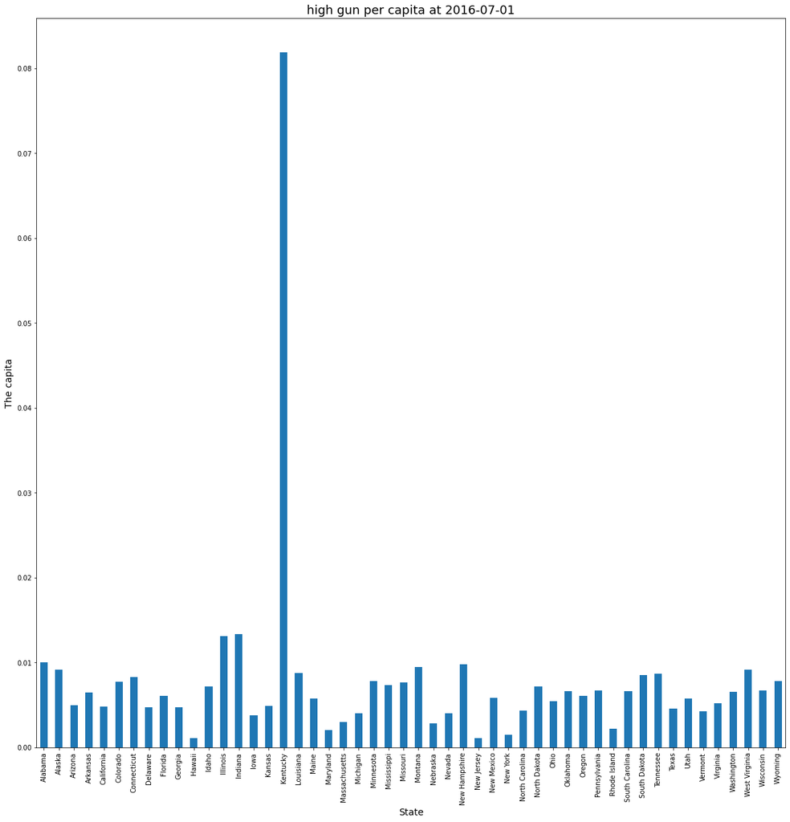

```python
fig_dims = (20,20)
fig, ax = plt.subplots(figsize=fig_dims)
avarge_2016.plot(kind = 'bar')
plt.title("high gun per capita at 2016-07-01",fontsize = 18)
plt.xlabel("State",fontsize=14)
plt.ylabel("The capita",fontsize=14)
```

## Conclusions

*The highest gun per capita is (0.08183167176548702) at 2016 in Kentucky*

*The least gun per capita is (0.0010955110646617531) at 2016 in Hawaii*

*Calcluate the high gun per capita at 2010-04-01*

```python
df_2010_capita = df_gun.query('month == "2010-04-01"')
```

```python
assert(df_2010_capita.state.tolist() == df_census_copy.iloc[:,3].index.tolist())
```

```python
df_2010_capita.set_index('state', inplace = True)
```

```python
avarge_2010 = df_2010_capita.totals / df_census_copy.iloc[:,3]
```

```python
avarge_2010.astype(float).idxmax()
```

```
'Kentucky'
```

```python
avarge_2010.loc['Kentucky']
```

```
0.04868475056384952
```

```python
avarge_2010.astype(float).idxmin()
```

```
'New Jersey'
```

```python
avarge_2010.loc['New Jersey']
```

```
0.00047941888289372006
```

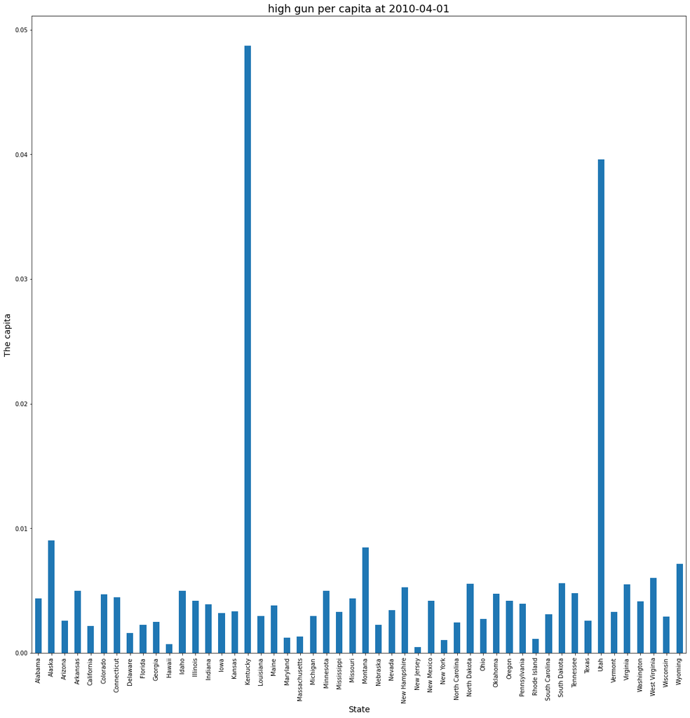

```python
fig_dims = (20,20)
fig, ax = plt.subplots(figsize=fig_dims)
avarge_2010.plot(kind = 'bar')
plt.title("high gun per capita at 2010-04-01",fontsize = 18)
plt.xlabel("State",fontsize=14)
plt.ylabel("The capita",fontsize=14)
```

## Conclusions

*The highest gun per capita is (0.04868475056384952) at 2010 in Kentucky*

*The least gun per capita is (0.00047941888289372006) at 2010 in New Jersey*

[figure not shown]

```python
df = pd.DataFrame([avarge_2010,avarge_2016],index=['2010-04-01','2016-07-01'])
df3 = df.transpose()
df3.plot(kind='line',figsize = (20,20))
plt.title("Comparing the capita between (2010-04-01 Vs 2016-06-01)",fontsize = 18)
plt.xlabel("State",fontsize=14)
plt.ylabel("The capita",fontsize=14)
```

## Conclusions

*The state of Kentucky got a rise in the per capita share of weapons during the period from 2010 to 2016, about 0.03*

*The state of Utah experienced a decrease in the per capita share of weapons between 2010 and 2016 by about 0.03*

### Which state has had the highest growth rate in weapons registrations?

### Which state has had the least growth rate in weapons registrations?

```python
gun_total = df_gun.groupby(['month','state'])['totals'].sum()
```

```python
pers = df_gun.month.max()
past = df_gun.month.min()
```

```python
groth = gun_total.loc[pers] - gun_total.loc[past]
groth_rate = (groth / gun_total.loc[past]) * 100
```

```python
groth_rate.idxmax()
```

```
'Illinois'
```

```python
groth_rate.loc['Illinois']
```

```
529213.6363636364
```

```python
groth_rate.idxmin()
```

```
'Iowa'
```

```python
groth_rate['Iowa']
```

```
1969.5020746887967
```

#### The minimum permits at states

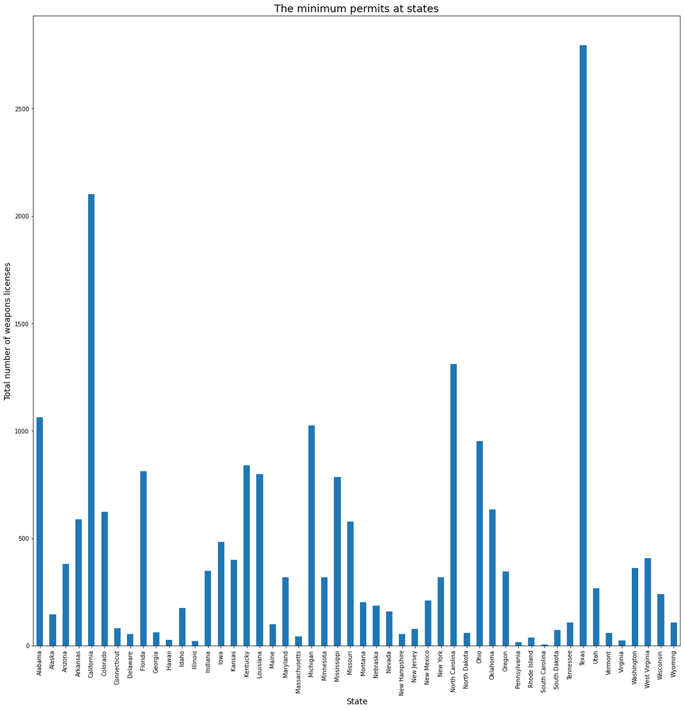

```python
ig_dims = (20,20)
fig, ax = plt.subplots(figsize=fig_dims)
gun_total.loc[past].plot(kind = 'bar')
plt.title("The minimum permits at states",fontsize = 18)
plt.xlabel("State",fontsize=14)
plt.ylabel("Total number of weapons licenses",fontsize=14)
```

## Conclusions

**South Carolina was the state with the lowest registration of weapons and it was recorded around 6 at 01-11-1998**

#### The maximum permits at states

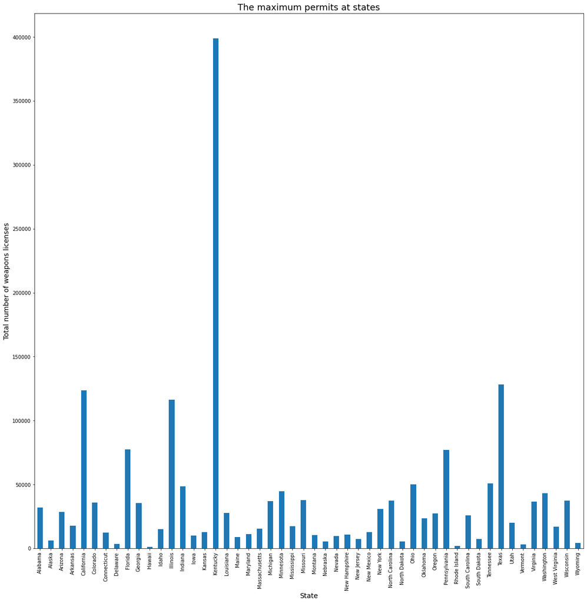

```python
ig_dims = (20,20)
fig, ax = plt.subplots(figsize=fig_dims)
gun_total.loc[pers].plot(kind = 'bar')
plt.title("The maximum permits at states",fontsize = 18)
plt.xlabel("State",fontsize=14)
plt.ylabel("Total number of weapons licenses",fontsize=14)
```

### Growth rate for states

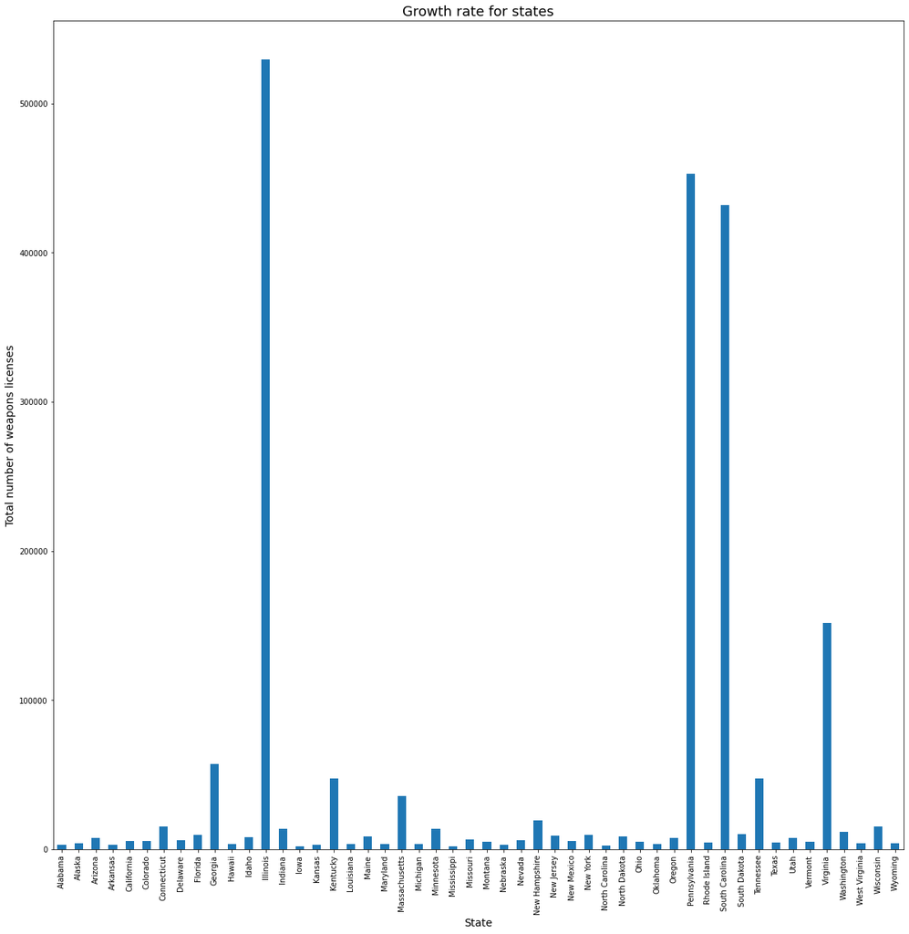

```python
ig_dims = (20,20)
fig, ax = plt.subplots(figsize=fig_dims)
groth_rate.plot(kind = 'bar')
plt.title("Growth rate for states",fontsize = 18)
plt.xlabel("State",fontsize=14)
plt.ylabel("Total number of weapons licenses",fontsize=14)
```

## Conclusions

*The highest growth rate in weapons registrations is (529213.6363636364) in Illinois stat*

*The least growth rate in weapons registrations is (1969.5020746887967) in Iowa state*

### What is the most purchased type of gun in 2017?

```python
#Make a new subdataframe 2017
df_017 = df_gun[df_gun['month'] == '2017-09' ]
df_017.head()
```

|  | month | state | permit | permit_recheck | handgun | long_gun | other | multiple | admin | prepawn_handgun | ... | returned_other | rentals_handgun | rentals_long_gun | private_sale_handgun | private_sale_long_gun | private_sale_other | return_to_seller_handgun | return_to_seller_long_gun | return_to_seller_other | totals |
| --- | --- | --- | --- | --- | --- | --- | --- | --- | --- | --- | --- | --- | --- | --- | --- | --- | --- | --- | --- | --- | --- |
| 0 | 2017-09-01 | Alabama | 16717.0 | 0.0 | 5734.0 | 6320.0 | 221.0 | 317.0 | 0.0 | 15.0 | ... | 0.0 | 0.0 | 0.0 | 9.0 | 16.0 | 3.0 | 0.0 | 0.0 | 3.0 | 32019.0 |
| 1 | 2017-09-01 | Alaska | 209.0 | 2.0 | 2320.0 | 2930.0 | 219.0 | 160.0 | 0.0 | 5.0 | ... | 0.0 | 0.0 | 0.0 | 17.0 | 24.0 | 1.0 | 0.0 | 0.0 | 0.0 | 6303.0 |
| 2 | 2017-09-01 | Arizona | 5069.0 | 382.0 | 11063.0 | 7946.0 | 920.0 | 631.0 | 0.0 | 13.0 | ... | 0.0 | 0.0 | 0.0 | 38.0 | 12.0 | 2.0 | 0.0 | 0.0 | 0.0 | 28394.0 |
| 3 | 2017-09-01 | Arkansas | 2935.0 | 632.0 | 4347.0 | 6063.0 | 165.0 | 366.0 | 51.0 | 12.0 | ... | 0.0 | 0.0 | 0.0 | 13.0 | 23.0 | 0.0 | 0.0 | 2.0 | 1.0 | 17747.0 |
| 4 | 2017-09-01 | California | 57839.0 | 0.0 | 37165.0 | 24581.0 | 2984.0 | 0.0 | 0.0 | 0.0 | ... | 0.0 | 0.0 | 0.0 | 0.0 | 0.0 | 0.0 | 0.0 | 0.0 | 0.0 | 123506.0 |

5 rows × 27 columns

```python
mos_p = df_017[['handgun', 'long_gun', 'other', 'multiple']]
mos_p.max()
```

```
handgun     39825.0
long_gun    39416.0
other        2984.0
multiple     2473.0
dtype: float64
```

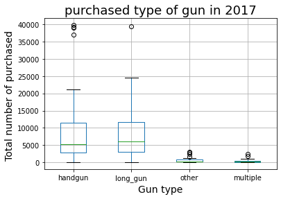

```python
mos_p.boxplot()
plt.title("purchased type of gun in 2017",fontsize = 18)
plt.xlabel("Gun type",fontsize=14)
plt.ylabel("Total number of purchased ",fontsize=14)
```

## Conclusions

**most purchased type of gun in 2017 is handgun and long_gun**

#### Relation between states and Total permit

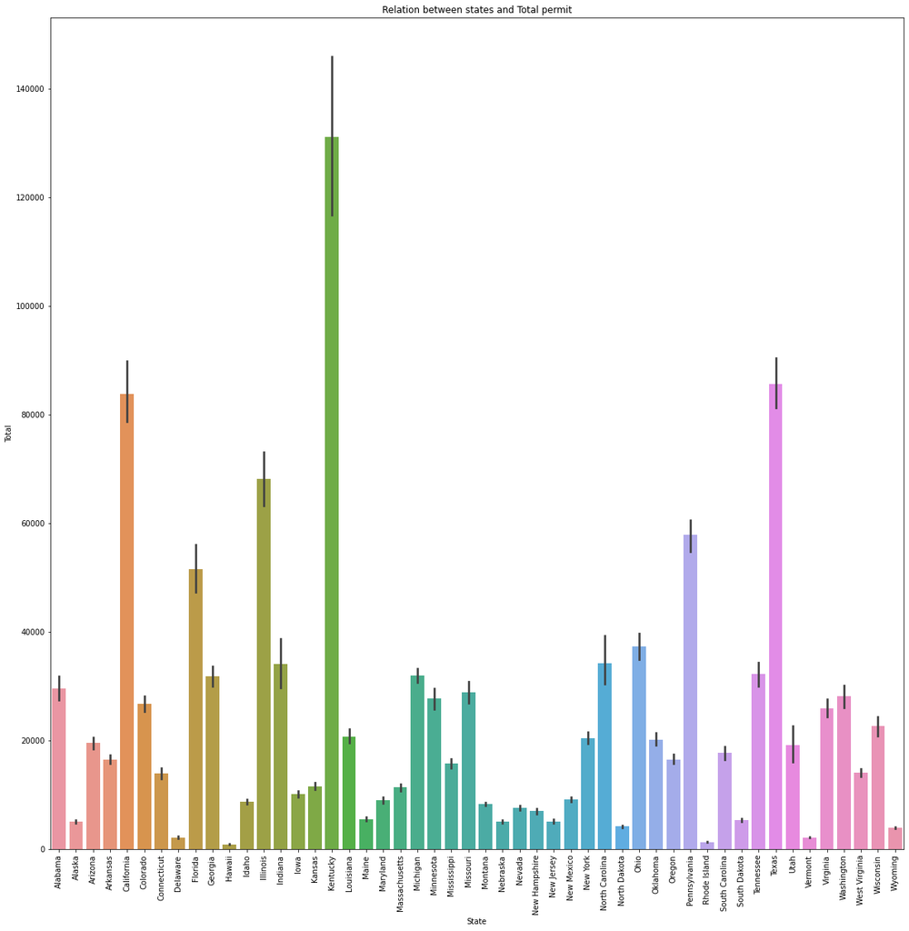

```python
fig_dims = (20,20)
fig, ax = plt.subplots(figsize=fig_dims)
plt.xticks(rotation=90);
sb.barplot(data=df_gun, x='state', y='totals');
plt.title('Relation between states and Total permit');
plt.xlabel('State')
plt.ylabel('Total');
```

## Conclusions

*The Kentucky has the the Highest registration of weapons*

# Conclusions

**In current study, a good amount of profound analysis has been carried out. Prior to each step, deailed instructions was given and interpretions was also provided afterwards. The dataset included 2 tables, but they have to be loaded by different measures. The data was ranging from 1998 to 2017, which consisted of detailed information of registered gun. Based on such substantial data, the analysis would be more reliable as opposed to small scale analysis.**

**The limitations of current study were obvious as well, data was seperated into two tables which could affect the process of analysis. On the other hand, the population estimation were only recorded for 2010 and 2016, which limit some analysis to a small range, same for many other parameters, such as "Foreign born persons, percent", "Veterans, 2011-2015", etc.**

## The limitations

*The least state in applying for permits in 19 years is South Carolina at 1998-11-01 by (6) permits*

*The highest gun per capita is (0.08183167176548702) at 2016 in Kentucky*

*The least gun per capita is (0.0010955110646617531) at 2016 in Hawaii*

*The highest gun per capita is (0.04868475056384952) at 2010 in Kentucky*

*The least gun per capita is (0.00047941888289372006) at 2010 in New Jersey*

**The highest growth rate in weapons registrations is (529213.6363636364) in Illinois stat***

*The least growth rate in weapons registrations is (1969.5020746887967) in Iowa state*

*most purchased type of gun in 2017 is handgun and long_gun*